# Atmospheric River Sequences as Indicators of Hydrologic Hazard in Historical Reanalysis and GFDL SPEAR Future Climate Projections

Corinne Bowers

2023-09-15

This markdown script reproduces the figures and numerical results associated with the paper “Atmospheric River Sequences as Indicators of Hydrologic Hazard in Historical Reanalysis and GFDL SPEAR Future Climate Projections” (https://doi.org/10.22541/essoar.167590838.86645781/v1), excepting Figure 2. Please note that the figures in the markdown file may not exactly match the published version because of formatting and scale differences.

# Setup

Load packages & functions

```r
source('_data/setup.R')
source('_scripts/create_df_functions.R')

## additional packages not in setup.R
library(patchwork)
library(pammtools)
library(assertthat)
library(devtools)
library(lubridate)

## progress bar
progress <- FALSE
if (progress) pb <- txtProgressBar(min = 0, max = ncell(grid_ca), style = 3)

## geospatial helpers
colors.huc <- colors.huc[c(6:10,1:5)]
cal <- st_union(california)

## download custom boxplot function for Figures XX & XX
source_url('https://github.com/BoulderCodeHub/CRSSIO/blob/master/R/stat_boxplot_custom.R?raw=TRUE')
```

Load MERRA-2 catalogs

```r
## 3-hour dataset
load('_scripts/_checkpoints/df_3hr_1209.Rdata')

## 24-hour dataset
load('_scripts/_checkpoints/df_24hr_0209.Rdata')

## date metadata
ts_merra <- seq(ymd_hms('1980-1-1 00:00:00'), ymd_hms('2021-12-31 21:00:00'), by = '3 hours')
dates_merra <- unique(as.Date(ts_merra))
```

Load GFDL catalogs

```r
## SPEAR historic
load('_scripts/_checkpoints/df_hist_1212.Rdata')

## SPEAR SSP 2-4.5
load('_scripts/_checkpoints/df_ssp245_1214.Rdata')

## SPEAR SSP 5-8.5
load('_scripts/_checkpoints/df_ssp585_1214.Rdata')

## SPEAR metadata
load('_data/GFDL/gfdl_metadata.Rdata')  #ts_hist, ts_future
ts_decades <- data.frame(ts = ts_future) %>%
  filter(year(ts) > 2020 & year(ts) <= 2090) %>%
  pull(ts)
decades <-
  data.frame(yr = 2021:2090) %>%
  mutate(decade = ceiling(yr/10)-202)
```

# 2) Methodology

## 2.2.1) Sequence Identification Algorithm

## FIG 1: Example sequence timeseries

Start-end parameter for example sequence timeseries:

```r
startend <-
  df_3hr[[167]] %>%
  filter(wateryear(ts) %in% 1981:2010) %>%
  pull(ivt) %>% median(na.rm = TRUE)

cat(paste('Example start-end parameter value:', round(startend,1), 'kg/m/s'))
```

```
## Example start-end parameter value: 91.9 kg/m/s
```

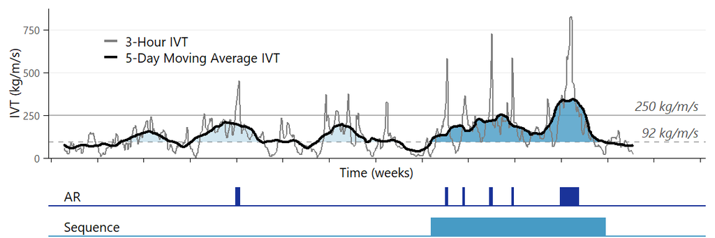

```r
## pull example data from historic record
df_example <- df_3hr[[167]] %>%
  filter(wateryear(ts) == 2016) %>%
  filter(month(ts) %in% 10:12) %>%
  filter(ts >= ymd_hms('2015-10-7 00:00:00')) %>%
  mutate(threshold1 = cbind(rolling5, startend) %>% apply(1, min)) %>%
  mutate(threshold2 = ifelse(seq.maxrolling > 250, rolling5, threshold1))

## create timeseries plot
g <- ggplot(df_example) +
  geom_hline(yintercept = 250, color = 'grey70') +
  geom_text(
    data = data.frame(x = max(df_example$ts), y = 250),
    aes(x=x, y=y, label = '250 kg/m/s'),
    # nudge_x = 3.1e5, nudge_y = 30,
    hjust = 1, vjust = -0.5, nudge_x = 8.5e5,
    family = 'Segoe UI', size = 8/.pt,fontface = 'italic', color = 'grey30') +
  geom_hline(yintercept = startend, color = 'grey70', linetype = 'dashed') +
  geom_text(
    data = data.frame(x = max(df_example$ts), y = 92),
    aes(x=x, y=y, label = '92 kg/m/s'),
    # nudge_x = 3.6e5, nudge_y = 30,
    hjust = 1, vjust = -0.5, nudge_x = 8.5e5,
    family = 'Segoe UI', size = 8/.pt, fontface = 'italic', color = 'grey30') +
  geom_ribbon(
    aes(x = ts, ymin = threshold1, ymax = rolling5),
    fill = roma.colors[4], alpha = 0.25) +
  geom_ribbon(
    aes(x = ts, ymin = threshold1, ymax = threshold2),
    fill = roma.colors[4], alpha = 0.75) +
  geom_line(aes(x = ts, y = ivt, color = '3-Hour IVT')) +
  geom_line(aes(x = ts, y = rolling5, color = '5-Day Moving Average IVT'), size = 0.75) +
  scale_color_manual('', values = c('grey50', 'black')) +
  scale_x_datetime(
    'Time (weeks)', date_breaks = '1 week',
    limits = c(min(df_example$ts), max(df_example$ts)+days(10)),
    expand = expansion(mult = c(0.025, 0.01))) +
  scale_y_origin('IVT (kg/m/s)', breaks = 250*(0:10)) +
  theme(
    text = element_text(family = 'Segoe UI', size = 8),
    legend.text = element_text(size = 8),
    axis.text.x = element_blank(),
    legend.position = c(0.1,0.8), legend.background = element_blank(),
    panel.grid.major.y = element_line(size = 0.25))

## create bar chart of AR days
g.ar <- ggplot(df_example) +
  pammtools::geom_stepribbon(
    aes(x = ts, ymin = 0, ymax = as.numeric(ar)),
    fill = roma.colors[5]) +
  geom_hline(yintercept = 0, color = roma.colors[5]) +
  geom_text(
    data = data.frame(x = min(df_example$ts), y = 0),
    aes(x=x, y=y, label = 'AR'),
    hjust = 0, vjust = -0.5,
    family = 'Segoe UI', size = 8/.pt, fontface = 'plain') +
  scale_x_datetime(
    limits = c(min(df_example$ts), max(df_example$ts)+days(10)),
    expand = expansion(mult = c(0.025, 0.01))) +
  theme_void()

## create bar chart of sequence days
g.seq <- ggplot(df_example) +
  pammtools::geom_stepribbon(
    aes(x = ts, ymin = 0, ymax = as.numeric(seq)),
    fill = roma.colors[4]) +
  geom_hline(yintercept = 0, color = roma.colors[4]) +
  geom_hline(yintercept = 1.5, color = 'white') +
  geom_text(
    data = data.frame(x = min(df_example$ts), y = 0),
    aes(x=x, y=y, label = 'Sequence'),
    hjust = 0, vjust = -0.5,
    family = 'Segoe UI', size = 8/.pt, fontface = 'plain') +
  scale_x_datetime(
    limits = c(min(df_example$ts), max(df_example$ts)+days(10)),
    expand = expansion(mult = c(0.025, 0.01))) +
  theme_void()

## combine into one plot and save
ggarrange(g, g.ar, g.seq, nrow = 3, heights = c(9,1,1.5), align = 'v')
ggsave('_figures/fig1_sequence.png', width = 6, height = 2, units = 'in', dpi = 600)
```

# 4) Results: Sequence Characteristics

## 4.1) Historical Characteristics

### Numerical results: Annual frequency statistics

Statewide average annual sequence frequency:

```r
nseq_ref <-
  foreach (i = 1:ncell(grid_ca), .combine = 'c') %do% {
    if (progress) setTxtProgressBar(pb,i)
    if (is.null(df_hist[[i]])) NA else {
      temp <- df_hist[[i]] %>%
        filter(wateryear(date) %in% 1981:2010) %>%
        filter(seq) %>%
        group_by(ens, seq.count) %>%
        summarize(duration = seq.duration[1], .groups = 'drop')
      nrow(temp)/length(unique(temp$ens))
    }
  }
nseq_ref <- nseq_ref / 30
if (progress) cat('\n')

cat(paste(
  'Mean annual frequency:',
  Mean(nseq_ref) %>% round(2), 'sequences/year \n'))
cat(paste(
  'Standard deviation:',
  sd(nseq_ref, na.rm = TRUE) %>% round(2), 'sequences/year \n'))
```

```
## Mean annual frequency: 1.47 sequences/year
## Standard deviation: 1.06 sequences/year
```

Statewide percentage of years with no sequences:

```r
nzero <-
  foreach (i = 1:ncell(grid_ca), .combine = 'c') %do% {
    if (progress) setTxtProgressBar(pb,i)
    if (is.null(df_hist[[i]])) NA else {
      temp <- df_hist[[i]] %>%
        filter(wateryear(date) %in% 1981:2010) %>%
        filter(seq) %>%
        group_by(ens, seq.count) %>%
        summarize(wy = wateryear(date[1]), duration = seq.duration[1], .groups = 'drop') %>%
        count(wy,ens) %>%
        right_join(
          expand.grid(wy = 1981:2010, ens = unique(temp$ens)),
          by = c('wy','ens')) %>%
        mutate(n = setNA(n,0))
      temp %>%
        group_by(ens) %>%
        summarize(zero = sum(n==0)) %>%
        pull(zero) %>% mean
    }
  }
if (progress) cat('\n')

cat(paste(
  'Mean number of years with no sequences:',
  Mean(nzero) %>% round(1), '\n'))
cat(paste(
  'Mean percentage of years with no sequences:',
  Mean(nzero/30) %>% percent(accuracy = 0.1)))
```

```
## Mean number of years with no sequences: 9.7
## Mean percentage of years with no sequences: 32.5%
```

Statewide average ARs per sequence in the historic record:

```r
nar_ref <-
  foreach (i = 1:ncell(grid_ca), .combine = 'c') %do% {
    if (progress) setTxtProgressBar(pb,i)
    if (!is.null(df_hist[[i]])) {
      df_hist[[i]] %>%
        filter(seq) %>%
        filter(wateryear(date) %in% 1981:2010) %>%
        group_by(ens,seq.count) %>%
        summarize(nar = length(unique(ar.count[!is.na(ar.count)])), .groups = 'drop') %>%
        summarize(nar.mean = Mean(nar)) %>% unlist %>% unname
    } else NA
  }
if (progress) cat('\n')

cat(paste(
  'Mean number of ARs per sequence:',
  Mean(nar_ref) %>% round(1), '\n'))
cat(paste(
  'Standard deviation of ARs per sequence:',
  sd(nar_ref, na.rm = TRUE) %>% round(2), '\n'))
```

```
## Mean number of ARs per sequence: 2.4
## Standard deviation of ARs per sequence: 0.24
```

### FIG 3: Historical Sequence Intensity and Duration

```r
historical <-
  foreach (i = 1:ncell(grid_ca), .combine = 'rbind') %do% {
    if (progress) setTxtProgressBar(pb,i)
    if (i %in% index_ca) {
      df_hist[[i]] %>%
        filter(wateryear(date) %in% 1981:2010) %>%
        filter(seq) %>%
        group_by(seq.count) %>%
        summarize(
          maxivt = seq.maxivt[1], duration = seq.duration[1], ens = ens[1]) %>%
        summarize(
          maxivt = mean(maxivt), duration = mean(duration),
          n.seq = length(seq.count)/length(unique(ens))/30) %>%
        cbind(
          df_hist[[i]] %>%
            filter(wateryear(date) %in% 1981:2010) %>%
            filter(ar) %>%
            group_by(ar.count) %>%
            summarize(pct.ar = mean(seq)) %>%
            summarize(pct.ar = mean(pct.ar)))
    } else rep(NA,4)
  }
historical <- historical %>%
  cbind(raster.df(grid_ca) %>% select(-value)) %>%
  slice(index_ca)
```

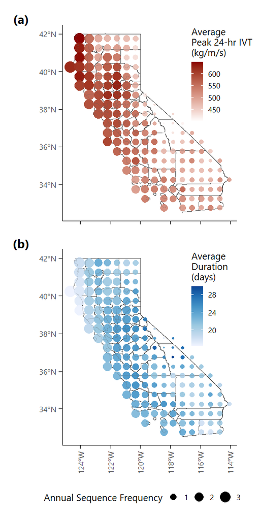

```r
g1 <- ggplot(historical) +
  geom_point(aes(x=x, y=y, color = maxivt, size = n.seq)) +
  geom_sf(data = california, fill = NA, size = 0.25) +
  geom_point(aes(x=x, y=y, color = maxivt, size = n.seq), alpha = 0.75) +
  scale_color_gradient(
    'Average \nPeak 24-hr IVT \n(kg/m/s)',
    low = 'white', high = 'darkred') +
  scale_size_area(max_size = 4, guide = guide_none()) +
  theme(
    legend.position = c(0.92, 0.75),
    axis.title = element_blank(),
    axis.text.x = element_blank(),
    # axis.text.x = element_text(angle = 90, vjust = 0.5),
    text = element_text(family = 'Segoe UI', size = 8))

g2 <- ggplot(historical) +
  geom_point(aes(x=x, y=y, color = duration, size = n.seq)) +
  geom_sf(data = california, fill = NA, size = 0.25) +
  geom_point(aes(x=x, y=y, color = duration, size = n.seq), alpha = 0.75) +
  scale_color_distiller(
    'Average \nDuration \n(days)',
    palette = 'Blues', direction = 1, breaks = 4*(0:10)) +
  scale_size_area(max_size = 4, guide = guide_none()) +
  theme(
    legend.position = c(0.85, 0.75),
    axis.title = element_blank(),
    # axis.text.y = element_blank(),
    axis.text.x = element_text(angle = 90, vjust = 0.5),
    text = element_text(family = 'Segoe UI', size = 8))

g3 <- ggplot(historical) +
  geom_point(aes(x=x, y=y, size = n.seq)) +
  scale_size_area('Annual Sequence Frequency', max_size = 4, breaks = 1:3) +
  theme(
    text = element_text(family = 'Segoe UI', size = 8),
    legend.position = 'bottom')

g1 + g2 + plot_spacer() +
  plot_layout(nrow = 3, heights = c(10,10,1)) +
  inset_element(
    get_legend(g3),
    left = 0.1, bottom = 0, top = 1, right = 1,
    ignore_tag = TRUE, align_to = 'full', on_top = TRUE) +
  plot_annotation(tag_levels = 'a', tag_prefix = '(', tag_suffix = ')') &
  theme(
    plot.tag = element_text(family = 'Segoe UI', face = 'bold', size = 10))
ggsave('_figures/fig3_historic.png', width = 3, height = 6, units = 'in', dpi = 600)
```

## 4.2) Projected Frequency Change

### Numerical results: Projected change in annual frequency

Create dataframes

```r
nseq_ssp245 <-
  foreach (i = 1:ncell(grid_ca), .combine = 'rbind') %do% {
    if (progress) setTxtProgressBar(pb,i)
    if (is.null(df_ssp245[[i]])) rep(NA,7) else {
      df_ssp245[[i]] %>%
        mutate(yr = year(date)) %>%
        right_join(decades, by = 'yr') %>%
        filter(seq) %>%
        group_by(ens, seq.count, decade) %>%
        summarize(duration = seq.duration[1], .groups = 'drop') %>%
        count(ens, decade) %>%
        group_by(decade) %>%
        summarize(nn = sum(n)/length(unique(ens))) %>%
        right_join(data.frame(decade = 1:7), by = 'decade') %>%
        arrange(decade) %>%
        mutate(nn = setNA(nn,0)) %>%
        pull(nn)
    }
  }
nseq_ssp245 <- nseq_ssp245 / 10
if (progress) cat('\n')

nseq_ssp585 <-
  foreach (i = 1:ncell(grid_ca), .combine = 'rbind') %do% {
    if (progress) setTxtProgressBar(pb,i)
    if (is.null(df_ssp585[[i]])) rep(NA,7) else {
      df_ssp585[[i]] %>%
        mutate(yr = year(date)) %>%
        right_join(decades, by = 'yr') %>%
        filter(seq) %>%
        group_by(ens, seq.count, decade) %>%
        summarize(duration = seq.duration[1], .groups = 'drop') %>%
        count(ens, decade) %>%
        group_by(decade) %>%
        summarize(nn = sum(n)/length(unique(ens))) %>%
        right_join(data.frame(decade = 1:7), by = 'decade') %>%
        arrange(decade) %>%
        mutate(nn = setNA(nn,0)) %>%
        pull(nn)
    }
  }
nseq_ssp585 <- nseq_ssp585 / 10
if (progress) cat('\n')

nseq_ssp245_eoc <-
  foreach (i = 1:ncell(grid_ca), .combine = 'c') %do% {
    if (progress) setTxtProgressBar(pb,i)
    if (is.null(df_ssp245[[i]])) NA else {
      temp <- df_ssp245[[i]] %>%
        filter(wateryear(date) %in% 2061:2090) %>%
        filter(seq) %>%
        group_by(ens, seq.count) %>%
        summarize(duration = seq.duration[1], .groups = 'drop')
      nrow(temp)/length(unique(temp$ens))
    }
  }
nseq_ssp245_eoc <- nseq_ssp245_eoc / 30
if (progress) cat('\n')

nseq_ssp585_eoc <-
  foreach (i = 1:ncell(grid_ca), .combine = 'c') %do% {
    if (progress) setTxtProgressBar(pb,i)
    if (is.null(df_ssp585[[i]])) NA else {
      temp <- df_ssp585[[i]] %>%
        filter(wateryear(date) %in% 2061:2090) %>%
        filter(seq) %>%
        group_by(ens, seq.count) %>%
        summarize(duration = seq.duration[1], .groups = 'drop')
      nrow(temp)/length(unique(temp$ens))
    }
  }
nseq_ssp585_eoc <- nseq_ssp585_eoc / 30
if (progress) cat('\n')
```

Change in sequence frequency by decade:

```r
frequency <-
  left_join(
    nseq_ssp245 %>% as.data.frame %>%
      cbind(hist = nseq_ref) %>%
      cbind(huc = grid_hucrep[]) %>%
      filter(huc > 0) %>%
      pivot_longer(cols = starts_with('V'), names_to = 'decade') %>%
      rename(ssp245 = value),
    nseq_ssp585 %>% as.data.frame %>%
      cbind(huc = grid_hucrep[]) %>%
      filter(huc > 0) %>%
      pivot_longer(cols = starts_with('V'), names_to = 'decade') %>%
      rename(ssp585 = value),
    by = c('huc', 'decade')) %>%
  mutate(
    decade = toNumber(gsub('V', '', decade)),
    decade_name = case_when(
      decade==1 ~ '2020s',
      decade==2 ~ '2030s',
      decade==3 ~ '2040s',
      decade==4 ~ '2050s',
      decade==5 ~ '2060s',
      decade==6 ~ '2070s',
      decade==7 ~ '2080s') %>% factor) %>%
  pivot_longer(cols = c(ssp245, ssp585), names_to = 'sim') %>%
  mutate(
    sim_name = case_when(
      sim == 'ssp245' ~ 'SSP 2-4.5 (Medium)',
      sim == 'ssp585' ~ 'SSP 5-8.5 (Very High)') %>%
      factor %>% factor(levels = levels(.))) %>%
  mutate(
    id = 1:nrow(.),
    tag = ifelse(id %in% 1:2, paste0('(', letters[id], ')'), NA))

frequency %>%
  group_by(decade_name, sim) %>%
  summarize(diff.mean = mean(value-hist), diff.sd = sd(value-hist), .groups = 'drop') %>%
  pivot_wider(names_from = sim, values_from = c(diff.mean, diff.sd), names_sep = '.') %>%
  gt() %>%
  tab_header('Change in Sequence Annual Frequency') %>%
  tab_spanner('SSP2-4.5', columns = ends_with('245')) %>%
  tab_spanner('SSP5-8.5', columns = ends_with('585')) %>%
  fmt_number(starts_with('diff'), decimals = 2) %>%
  cols_label(
    decade_name = 'Decade',
    diff.mean.ssp245 = 'Mean',
    diff.sd.ssp245 = 'Std.Dev.',
    diff.mean.ssp585 = 'Mean',
    diff.sd.ssp585 = 'Std.Dev') %>%
  tab_options(
    heading.background.color = '#d9d9d9',
    column_labels.background.color = '#f2f2f2')
```

Change in Sequence Annual Frequency

| Decade | SSP2-4.5 Mean | SSP2-4.5 Std.Dev. | SSP5-8.5 Mean | SSP5-8.5 Std.Dev |
| --- | --- | --- | --- | --- |
| 2020s | 0.13 | 0.11 | 0.25 | 0.20 |
| 2030s | 0.37 | 0.10 | 0.25 | 0.19 |
| 2040s | 0.22 | 0.19 | 0.54 | 0.15 |
| 2050s | 0.51 | 0.15 | 0.82 | 0.27 |
| 2060s | 0.59 | 0.19 | 0.78 | 0.14 |
| 2070s | 0.59 | 0.08 | 0.86 | 0.31 |
| 2080s | 0.72 | 0.16 | 1.13 | 0.17 |

### FIG 4: Projected change in sequence annual frequency by decade

Note: Additional labels were added to this figure in Inkscape.

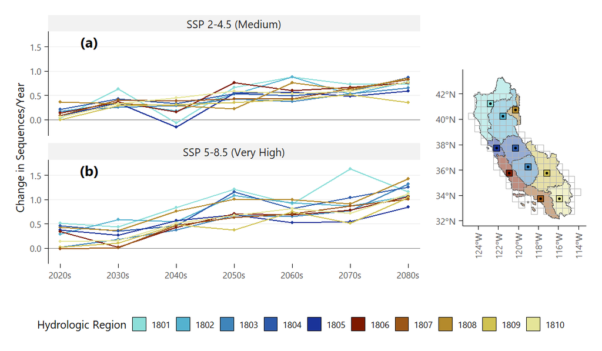

```r
g.additive <-
  ggplot(frequency) +
  geom_hline(yintercept = 0, color = 'grey50', size = 0.35) +
  geom_line(
    aes(x = decade_name, y = value-hist, group = huc, color = factor(huc)),
    size = 0.5) +
  geom_point(
    aes(x = decade_name, y = value-hist, group = huc, color = factor(huc)),
    size = 0.75) +
  geom_text(
    aes(x = 1.5, y = 1.6, label = tag),
    size = 10/.pt, family = 'Segoe UI', fontface = 'bold') +
  facet_wrap(~sim_name, nrow = 2) +
  scale_color_manual(values = colors.huc, guide = guide_none()) +
  scale_x_discrete(expand = expansion(mult = 0.035)) +
  scale_y_continuous(
    # 'Frequency Change Relative to WY 1981-2010',
    'Change in Sequences/Year',
    # labels = percent,
    expand = expansion(mult = 0.1)) +
  theme(
    text = element_text(family = 'Segoe UI', size = 8),
    panel.grid.major.y = element_line(size = 0.25),
    strip.background = element_rect(color = NA, fill = 'grey95'),
    strip.text = element_text(size = 8, margin = margin(2,0,2,0)),
    axis.line.x = element_blank(),
    axis.title.x = element_blank())

gmap <- ggplot(huc4) +
  geom_sf(aes(fill = factor(huc4)), alpha = 0.5, size = 0.25) +
  scale_fill_manual('Hydrologic Region', values = colors.huc) +
  geom_tile(
    data = raster.df(grid_ca) %>% filter(!is.na(value)),
    aes(x=x, y=y), color = 'grey70', fill = NA) +
  geom_tile(
    data = raster.df(grid_hucrep) %>% filter(value>0),
    aes(x=x, y=y, fill = factor(value)), color = 'black') +
  geom_point(
    data = raster.df(grid_hucrep) %>% filter(value>0),
    aes(x=x, y=y), color = 'black', size = 0.5) +
  guides(fill = guide_legend(nrow = 1)) +
  theme(
    text = element_text(family = 'Segoe UI', size = 8),
    # panel.border = element_rect(fill = NA, size = 0.25),
    # axis.line = element_blank(),
    axis.text.x = element_text(angle = 90, vjust = 0.5),
    axis.title = element_blank(),
    legend.position = 'bottom',
    legend.background = element_rect(fill = NA),
    legend.title = element_text(margin = margin(0,0,0,0)),
    legend.text = element_text(margin = margin(0,0,0,0)),
    legend.margin = margin(c(0,0,0,0)))
gmap_blank <- gmap + guides(fill = guide_none())

layout = 'AAAB\nCCCC'
g.additive + gmap_blank + get_legend(gmap) + plot_spacer() +
  plot_layout(design = layout, heights = c(10,1))
ggsave('_figures/fig4.png', width = 6, height = 3.5, units = 'in', dpi = 600)
```

### Change in number of ARs per sequence

```r
nar_ssp245 <-
  foreach (i = 1:ncell(grid_ca), .combine = 'rbind') %do% {
    if (progress) setTxtProgressBar(pb,i)
    if (!is.null(df_ssp245[[i]])) {
      df_ssp245[[i]] %>%
        mutate(yr = year(date)) %>%
        right_join(decades, by = 'yr') %>%
        filter(seq) %>%
        group_by(ens, decade, seq.count) %>%
        summarize(nar = length(unique(ar.count[!is.na(ar.count)])), .groups = 'drop') %>%
        group_by(decade) %>%
        summarize(nar = mean(nar)) %>%
        right_join(data.frame(decade = 1:7), by = 'decade') %>%
        arrange(decade) %>%
        pull(nar)
    } else rep(NA,7)
  }
if (progress) cat('\n')

nar_ssp585 <-
  foreach (i = 1:ncell(grid_ca), .combine = 'rbind') %do% {
    if (progress) setTxtProgressBar(pb,i)
    if (!is.null(df_ssp585[[i]])) {
      df_ssp585[[i]] %>%
        mutate(yr = year(date)) %>%
        right_join(decades, by = 'yr') %>%
        filter(seq) %>%
        group_by(ens, decade, seq.count) %>%
        summarize(nar = length(unique(ar.count[!is.na(ar.count)])), .groups = 'drop') %>%
        group_by(decade) %>%
        summarize(nar = mean(nar)) %>%
        right_join(data.frame(decade = 1:7), by = 'decade') %>%
        arrange(decade) %>%
        pull(nar)
    } else rep(NA,7)
  }
if (progress) cat('\n')
```

```r
nar <-
  left_join(
    nar_ssp245 %>% as.data.frame %>%
      cbind(hist = nar_ref) %>%
      cbind(huc = grid_hucrep[]) %>%
      filter(huc > 0) %>%
      pivot_longer(cols = starts_with('V'), names_to = 'decade') %>%
      rename(ssp245 = value),
    nar_ssp585 %>% as.data.frame %>%
      cbind(huc = grid_hucrep[]) %>%
      filter(huc > 0) %>%
      pivot_longer(cols = starts_with('V'), names_to = 'decade') %>%
      rename(ssp585 = value),
    by = c('huc', 'decade')) %>%
  mutate(
    decade = toNumber(gsub('V', '', decade)),
    decade_name = case_when(
      decade==1 ~ '2020s',
      decade==2 ~ '2030s',
      decade==3 ~ '2040s',
      decade==4 ~ '2050s',
      decade==5 ~ '2060s',
      decade==6 ~ '2070s',
      decade==7 ~ '2080s') %>% factor) %>%
  pivot_longer(cols = c(ssp245, ssp585), names_to = 'sim') %>%
  mutate(
    sim_name = case_when(
      sim == 'ssp245' ~ 'SSP 2-4.5 (Medium)',
      sim == 'ssp585' ~ 'SSP 5-8.5 (Very High)') %>%
      factor %>% factor(levels = levels(.)))

nar %>%
  group_by(decade_name, sim) %>%
  summarize(diff.mean = mean(value-hist), diff.sd = sd(value-hist), .groups = 'drop') %>%
  pivot_wider(names_from = sim, values_from = c(diff.mean, diff.sd), names_sep = '.') %>%
  gt() %>%
  tab_header('Change in ARs per Sequence') %>%
  tab_spanner('SSP2-4.5', columns = ends_with('245')) %>%
  tab_spanner('SSP5-8.5', columns = ends_with('585')) %>%
  fmt_number(starts_with('diff'), decimals = 2) %>%
  cols_label(
    decade_name = 'Decade',
    diff.mean.ssp245 = 'Mean',
    diff.sd.ssp245 = 'Std.Dev.',
    diff.mean.ssp585 = 'Mean',
    diff.sd.ssp585 = 'Std.Dev') %>%
  tab_options(
    heading.background.color = '#d9d9d9',
    column_labels.background.color = '#f2f2f2')
```

Change in ARs per Sequence

| Decade | SSP2-4.5 Mean | SSP2-4.5 Std.Dev. | SSP5-8.5 Mean | SSP5-8.5 Std.Dev |
| --- | --- | --- | --- | --- |
| 2020s | −0.02 | 0.24 | 0.07 | 0.20 |
| 2030s | 0.06 | 0.24 | 0.21 | 0.18 |
| 2040s | 0.00 | 0.11 | 0.25 | 0.24 |
| 2050s | 0.08 | 0.19 | 0.21 | 0.21 |
| 2060s | 0.29 | 0.21 | 0.46 | 0.28 |
| 2070s | 0.24 | 0.29 | 0.44 | 0.22 |
| 2080s | 0.32 | 0.12 | 0.59 | 0.27 |

### Change in percentage of ARs falling within sequences

```r
pctar_ref <-
  foreach (i = 1:ncell(grid_ca), .combine = 'c') %do% {
    if (progress) setTxtProgressBar(pb,i)
    if (!is.null(df_hist[[i]])) {
      df_hist[[i]] %>%
        filter(ar) %>%
        filter(wateryear(date) %in% 1981:2010) %>%
        group_by(ens,ar.count) %>%
        summarize(pctar = sum(seq)/length(seq)>0, .groups = 'drop') %>%
        pull(pctar) %>% mean
    } else NA
  }
if (progress) cat('\n')

pctar_ssp245 <-
  foreach (i = 1:ncell(grid_ca), .combine = 'rbind') %do% {
    if (progress) setTxtProgressBar(pb,i)
    if (!is.null(df_ssp245[[i]])) {
      df_ssp245[[i]] %>%
        mutate(yr = year(date)) %>%
        right_join(decades, by = 'yr') %>%
        filter(ar) %>%
        group_by(ens, decade, ar.count) %>%
        summarize(pctar = sum(seq)/length(seq)>0, .groups = 'drop') %>%
        group_by(decade) %>%
        summarize(pctar = mean(pctar)) %>%
        right_join(data.frame(decade = 1:7), by = 'decade') %>%
        arrange(decade) %>%
        pull(pctar)
    } else rep(NA,7)
  }
if (progress) cat('\n')

pctar_ssp585 <-
  foreach (i = 1:ncell(grid_ca), .combine = 'rbind') %do% {
    if (progress) setTxtProgressBar(pb,i)
    if (!is.null(df_ssp585[[i]])) {
      df_ssp585[[i]] %>%
        mutate(yr = year(date)) %>%
        right_join(decades, by = 'yr') %>%
        filter(ar) %>%
        group_by(ens, decade, ar.count) %>%
        summarize(pctar = sum(seq)/length(seq)>0, .groups = 'drop') %>%
        group_by(decade) %>%
        summarize(pctar = mean(pctar)) %>%
        right_join(data.frame(decade = 1:7), by = 'decade') %>%
        arrange(decade) %>%
        pull(pctar)
    } else rep(NA,7)
  }
if (progress) cat('\n')
```

```r
pctar <-
  left_join(
    pctar_ssp245 %>% as.data.frame %>%
      cbind(hist = pctar_ref) %>%
      cbind(huc = grid_hucrep[]) %>%
      filter(huc > 0) %>%
      pivot_longer(cols = starts_with('V'), names_to = 'decade') %>%
      rename(ssp245 = value),
    pctar_ssp585 %>% as.data.frame %>%
      cbind(huc = grid_hucrep[]) %>%
      filter(huc > 0) %>%
      pivot_longer(cols = starts_with('V'), names_to = 'decade') %>%
      rename(ssp585 = value),
    by = c('huc', 'decade')) %>%
  mutate(
    decade = toNumber(gsub('V', '', decade)),
    decade_name = case_when(
      decade==1 ~ '2020s',
      decade==2 ~ '2030s',
      decade==3 ~ '2040s',
      decade==4 ~ '2050s',
      decade==5 ~ '2060s',
      decade==6 ~ '2070s',
      decade==7 ~ '2080s') %>% factor) %>%
  pivot_longer(cols = c(ssp245, ssp585), names_to = 'sim') %>%
  mutate(
    sim_name = case_when(
      sim == 'ssp245' ~ 'SSP 2-4.5 (Medium)',
      sim == 'ssp585' ~ 'SSP 5-8.5 (Very High)') %>%
      factor %>% factor(levels = levels(.)))

pctar %>%
  group_by(decade_name, sim) %>%
  summarize(diff.mean = mean(value-hist), diff.sd = sd(value-hist), .groups = 'drop') %>%
  pivot_wider(names_from = sim, values_from = c(diff.mean, diff.sd), names_sep = '.') %>%
  gt() %>%
  tab_header('Change in Percentage of ARs Within Sequences') %>%
  tab_spanner('SSP2-4.5', columns = ends_with('245')) %>%
  tab_spanner('SSP5-8.5', columns = ends_with('585')) %>%
  fmt_percent(starts_with('diff'), decimals = 1) %>%
  cols_label(
    decade_name = 'Decade',
    diff.mean.ssp245 = 'Mean',
    diff.sd.ssp245 = 'Std.Dev.',
    diff.mean.ssp585 = 'Mean',
    diff.sd.ssp585 = 'Std.Dev') %>%
  tab_options(
    heading.background.color = '#d9d9d9',
    column_labels.background.color = '#f2f2f2')
```

Change in Percentage of ARs Within Sequences

| Decade | SSP2-4.5 Mean | SSP2-4.5 Std.Dev. | SSP5-8.5 Mean | SSP5-8.5 Std.Dev |
| --- | --- | --- | --- | --- |
| 2020s | −4.2% | 7.7% | −1.3% | 3.5% |
| 2030s | 1.4% | 5.8% | −1.2% | 5.8% |
| 2040s | −1.9% | 10.3% | 2.5% | 8.8% |
| 2050s | 1.1% | 7.5% | 5.7% | 5.4% |
| 2060s | −0.9% | 8.8% | 1.5% | 5.6% |
| 2070s | 1.1% | 8.3% | 2.2% | 8.4% |
| 2080s | 3.3% | 8.1% | 8.2% | 4.6% |

## 4.3) Projected Intensity Change

### Numerical results: Projected relative change in sequence intensity

Create dataframes

```r
stats_ref <-
  foreach (i = 1:ncell(grid_ca), .combine = 'rbind') %do% {
    if (progress) setTxtProgressBar(pb,i)
    if (!is.null(df_hist[[i]])) {
      df_hist[[i]] %>%
        filter(wateryear(date) %in% 1981:2010) %>%
        filter(seq) %>%
        group_by(ens,seq.count) %>%
        summarize(maxivt = seq.maxivt[1], duration = seq.duration[1], .groups = 'drop') %>%
        summarize(
          maxivt.med = median(maxivt),
          maxivt.q95 = quantile(maxivt,0.95),
          duration.med = median(duration),
          duration.q95 = quantile(duration,0.95))
    } else rep(NA,4)
  }
if (progress) cat('\n')

stats_ssp245_eoc <-
  foreach (i = 1:ncell(grid_ca), .combine = 'rbind') %do% {
    if (progress) setTxtProgressBar(pb,i)
    if (!is.null(df_ssp245[[i]])) {
      df_ssp245[[i]] %>%
        filter(wateryear(date) %in% 2061:2090) %>%
        filter(seq) %>%
        group_by(ens,seq.count) %>%
        summarize(maxivt = seq.maxivt[1], duration = seq.duration[1], .groups = 'drop') %>%
        summarize(
          maxivt.med = median(maxivt, na.rm = TRUE),
          maxivt.q95 = quantile(maxivt,0.95, na.rm = TRUE),
          duration.med = median(duration, na.rm = TRUE),
          duration.q95 = quantile(duration,0.95, na.rm = TRUE))
    } else rep(NA,4)
  }
if (progress) cat('\n')

stats_ssp585_eoc <-
  foreach (i = 1:ncell(grid_ca), .combine = 'rbind') %do% {
    if (progress) setTxtProgressBar(pb,i)
    if (!is.null(df_ssp585[[i]])) {
      df_ssp585[[i]] %>%
        filter(wateryear(date) %in% 2061:2090) %>%
        filter(seq) %>%
        group_by(ens,seq.count) %>%
        summarize(maxivt = seq.maxivt[1], duration = seq.duration[1], .groups = 'drop') %>%
        summarize(
          maxivt.med = median(maxivt, na.rm = TRUE),
          maxivt.q95 = quantile(maxivt,0.95, na.rm = TRUE),
          duration.med = median(duration, na.rm = TRUE),
          duration.q95 = quantile(duration,0.95, na.rm = TRUE))
    } else rep(NA,4)
  }
if (progress) cat('\n')

stats <-
  rbind(
    df_hist[[which(grid_hucrep[]==1804)]] %>%
      filter(wateryear(date) %in% 1981:2010) %>%
      filter(seq) %>%
      group_by(ens,seq.count) %>%
      summarize(maxivt = seq.maxivt[1], duration = seq.duration[1], .groups = 'drop') %>%
      mutate(source = 'hist'),
    df_ssp245[[which(grid_hucrep[]==1804)]] %>%
      filter(wateryear(date) %in% 2061:2090) %>%
      filter(seq) %>%
      group_by(ens,seq.count) %>%
      summarize(maxivt = seq.maxivt[1], duration = seq.duration[1], .groups = 'drop') %>%
      mutate(source = 'ssp245'),
    df_ssp585[[which(grid_hucrep[]==1804)]] %>%
      filter(wateryear(date) %in% 2061:2090) %>%
      filter(seq) %>%
      group_by(ens,seq.count) %>%
      summarize(maxivt = seq.maxivt[1], duration = seq.duration[1], .groups = 'drop') %>%
      mutate(source = 'ssp585')) %>%
  mutate(
    source_name = case_when(
      source == 'hist' ~ 'Historic',
      source == 'ssp245' ~ 'SSP 2-4.5',
      source == 'ssp585' ~ 'SSP 5-8.5') %>%
      factor %>% factor(levels = levels(.)[3:1]))
```

Filter distribution statistics to focus on sequence intensity

```r
intensity <-
  cbind(
    (stats_ssp245_eoc / stats_ref) %>%
      select(starts_with('maxivt')) %>%
      setNames(gsub('maxivt', 'ssp245', names(.))),
    (stats_ssp585_eoc / stats_ref) %>%
      select(starts_with('maxivt')) %>%
      setNames(gsub('maxivt', 'ssp585', names(.)))) %>%
    cbind(raster.df(grid_ca) %>% select(-value)) %>%
    slice(index_ca) %>%
    pivot_longer(cols = c(-x,-y)) %>%
    separate(name, into = c('sim', 'stat')) %>%
    mutate(
      sim_name = case_when(
        sim == 'ssp245' ~ 'SSP 2-4.5',
        sim == 'ssp585' ~ 'SSP 5-8.5') %>%
        factor %>% factor(levels = levels(.)[2:1]),
      stat_name = case_when(
        stat == 'med' ~ 'Median',
        stat == 'q95' ~ '95th Percentile') %>%
        factor %>% factor(levels = levels(.)[3:1]))
```

Relative intensity change for HUC1804:

```r
left_join(
  stats_ssp245_eoc %>%
    select(starts_with('maxivt')) %>%
    cbind(huc = grid_hucrep[]) %>%
    filter(huc == 1804) %>%
    select(-huc) %>%
    pivot_longer(everything(), names_to = 'stat', values_to = 'ssp245'),
  stats_ref %>%
    select(starts_with('maxivt')) %>%
    cbind(huc = grid_hucrep[]) %>%
    filter(huc == 1804) %>%
    select(-huc) %>%
    pivot_longer(everything(), names_to = 'stat', values_to = 'hist'),
  by = 'stat') %>%
  mutate(
    stat = gsub('maxivt.', '', stat),
    stat_name = case_when(
      stat == 'med' ~ 'Median',
      stat == 'q95' ~ '95th Percentile') %>%
      factor %>% factor(levels = levels(.)[3:1])) %>%
  mutate(fact = ssp245/hist, pct = fact-1) %>%
  select(stat_name, hist, ssp245, fact, pct) %>%
  gt %>%
  tab_header(
    'Relative Change Calculation',
    subtitle = 'Sequence Intensity (Peak 24-Hour IVT, kg/m/s)') %>%
  fmt_number(c(hist,ssp245), decimals = 0) %>%
  fmt_number(fact, decimals = 2) %>%
  fmt_percent(pct, decimals = 0) %>%
  cols_label(
    stat_name = 'Statistic',
    hist = 'Historic',
    ssp245 = 'SSP2-4.5',
    fact = 'Change Factor',
    pct = 'Percent Change') %>%
  tab_options(
    heading.background.color = '#d9d9d9',
    column_labels.background.color = '#f2f2f2')
```

Relative Change Calculation

Sequence Intensity (Peak 24-Hour IVT, kg/m/s)

| Statistic | Historic | SSP2-4.5 | Change Factor | Percent Change |
| --- | --- | --- | --- | --- |
| Median | 539 | 576 | 1.07 | 7% |
| 95th Percentile | 715 | 832 | 1.16 | 16% |

Statewide average relative intensity change:

```r
intensity %>%
  group_by(sim, stat) %>%
  summarize(mean = Mean(value)-1, sd = sd(value, na.rm = TRUE), .groups = 'drop') %>%
  # mutate(pct.mean = round(100*(fact.mean-1),1), pct.sd = round(100*fact.sd,1)) %>%
  mutate(sim_name = ifelse(sim == 'ssp245', 'SSP2-4.5', 'SSP5-8.5')) %>%
  select(-sim) %>%
  pivot_wider(names_from = stat, values_from = c(mean,sd), names_sep = '.') %>%
  select(sim_name, ends_with('med'), ends_with('iqr'), ends_with('q95')) %>%
  gt %>%
  tab_header(
    'Relative Change in Statewide Average Statistics',
    subtitle = 'Sequence Intensity (Peak 24-Hour IVT, kg/m/s)') %>%
  tab_spanner('Median', columns = ends_with('med')) %>%
  tab_spanner('IQR', columns = ends_with('iqr')) %>%
  tab_spanner('95th Percentile', columns = ends_with('q95')) %>%
  fmt_percent(c(starts_with('mean'), starts_with('sd')), decimals = 1) %>%
  cols_label(
    sim_name = 'Emission Scenario',
    mean.med = 'Mean', sd.med = 'Std.Dev.',
    mean.q95 = 'Mean', sd.q95 = 'Std.Dev.') %>%
  tab_options(
    heading.background.color = '#d9d9d9',
    column_labels.background.color = '#f2f2f2')
```

Relative Change in Statewide Average Statistics

Sequence Intensity (Peak 24-Hour IVT, kg/m/s)

| Emission Scenario | Median Mean | Median Std.Dev. | 95th Percentile Mean | 95th Percentile Std.Dev. |
| --- | --- | --- | --- | --- |
| SSP2-4.5 | 6.5% | 4.3% | 12.7% | 6.2% |
| SSP5-8.5 | 11.6% | 5.6% | 19.1% | 5.7% |

### FIG 5: Sequence intensity change

Top row (a,b):

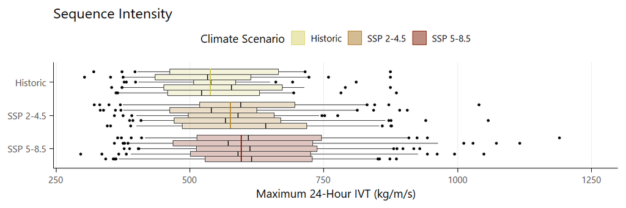

```r
a <- ggplot(stats) +
  geom_ribbon(
    aes(x = maxivt, group = source, ymin = source_name, ymax = source_name, fill = source),
    color = NA, alpha = 0) +
  # stat_boxplot_custom(
  #   aes(x = maxivt, y = source_name, group = paste(source,ens), fill = source),
  #   qs = c(.05, .25, .5, .75, .95),
  #   outlier.size = 0.5, size = 0.25, outlier.alpha = 1, alpha = 0.25,
  #   show.legend = FALSE) +
  geom_boxplot(
    data = stats %>%
      mutate(source_name = factor(source_name, levels = c('SSP 5-8.5','SSP 2-4.5','Historic'))) %>%
      group_by(source_name,source,ens) %>%
      summarize(
        y05 = quantile(maxivt,0.05),
        y25 = quantile(maxivt,0.25),
        y50 = quantile(maxivt,0.50),
        y75 = quantile(maxivt,0.75),
        y95 = quantile(maxivt,0.95)),
    aes(
      xmin = y05, xlower = y25, xmiddle = y50, xupper = y75, xmax = y95,
      y = source_name, group = paste(source_name,ens), fill = source),
    stat = 'identity', position = 'dodge',
    width = 0.8, size = 0.25, alpha = 0.25, show.legend = FALSE) +
  geom_point(
    data = stats %>%
      mutate(source_name = factor(source_name, levels = c('SSP 5-8.5','SSP 2-4.5','Historic'))) %>%
      group_by(source_name,source,ens) %>%
      mutate(
        y05 = quantile(maxivt,0.05),
        y95 = quantile(maxivt,0.95)) %>%
      ungroup %>% group_by(source) %>%
      mutate(
        dodge = seq(-0.32,0.32,length.out = length(unique(ens)))[ens]) %>%
      ungroup %>%
      filter(maxivt < y05 | maxivt > y95),
    aes(x = maxivt, y = as.numeric(factor(source_name))+dodge),
    size = 0.5) +
  scale_fill_manual(
    'Climate Scenario',
    labels = c('Historic', 'SSP 2-4.5', 'SSP 5-8.5'),
    values = scico(7, palette = 'roma')[3:1],
    guide = guide_legend(
      override.aes = list(
        color = scico(7, palette = 'roma')[3:1], size = 0.25, alpha = 0.5))) +
  scale_x_continuous(
    'Maximum 24-Hour IVT (kg/m/s)', breaks = 250*(0:10),
    limits = c(250,1250), expand = expansion(mult = c(0.005,0.05))) +
  theme(
    text = element_text(family = 'Segoe UI', size = 8),
    panel.grid.major.x = element_line(size = 0.25),
    axis.title.y = element_blank(),
    legend.position = 'top',
    legend.margin = margin(1,1,1,1)) + #c(0.9, 0.75)) +
  ggtitle('Sequence Intensity') +
  geom_segment(
    x = stats %>% filter(source == 'hist') %>% pull(maxivt) %>% median,
    xend = stats %>% filter(source == 'hist') %>% pull(maxivt) %>% median,
    y = 2.6, yend = 3.4,
    color = scico(11, palette = 'roma')[4]) +
  geom_segment(
    x = stats %>% filter(source == 'ssp245') %>% pull(maxivt) %>% median,
    xend = stats %>% filter(source == 'ssp245') %>% pull(maxivt) %>% median,
    y = 1.6, yend = 2.4,
    color = scico(11, palette = 'roma')[3]) +
  geom_segment(
    x = stats %>% filter(source == 'ssp585') %>% pull(maxivt) %>% median,
    xend = stats %>% filter(source == 'ssp585') %>% pull(maxivt) %>% median,
    y = 0.6, yend = 1.4,
    color = scico(11, palette = 'roma')[1])
a
```

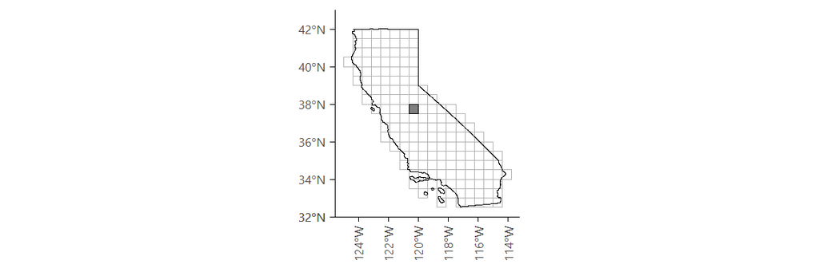

```r
b <- ggplot() +
  geom_tile(
    data = raster.df(grid_hucrep),
    aes(x=x, y=y, fill = value==1804)) +
  scale_fill_manual(
    values = c('white', 'grey50'), guide = guide_none()) +
  geom_tile(
    data = raster.df(grid_hucrep*grid_ca/grid_ca) %>% arrange(value==1804),
    aes(x=x, y=y, color = value==1804), fill = NA) +
  scale_color_manual(
    values = c('grey70', 'black'), na.value = NA, guide = guide_none()) +
  geom_sf(data = cal, fill = NA, color = 'black', size = 0.25) +
  theme(
    text = element_text(family = 'Segoe UI', size = 8),
    axis.text.x = element_text(angle = 90, vjust = 0.5),
    axis.title = element_blank(),
    legend.background = element_rect(fill = NA))
b
```

Bottom row (c,d,e):

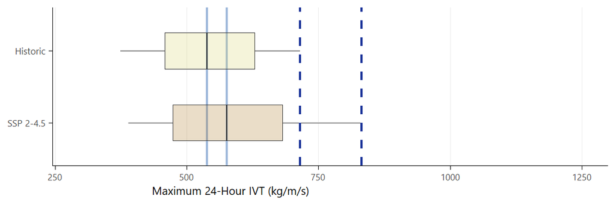

```r
c <- ggplot(stats %>% filter(source != 'ssp585')) +
  ## medians
  geom_vline(
    xintercept = stats %>% filter(source == 'hist') %>% pull(maxivt) %>% median,
    size = 0.75, color = baker[3]) +
  geom_vline(
    xintercept = stats %>% filter(source == 'ssp245') %>% pull(maxivt) %>% median,
    size = 0.75, color = baker[3]) +
  ## boxplot
  # stat_boxplot_custom(
  #   aes(x = maxivt, y = source_name, fill = source),
  #   qs = c(.05, .25, .5, .75, .95),
  #   outlier.size = 0.5, size = 0.25, outlier.alpha = 0, alpha = 0.25,
  #   width = 0.5,
  #   show.legend = FALSE) +
  geom_boxplot(
    data = stats %>% filter(source != 'ssp585') %>%
      mutate(source_name = factor(source_name, levels = c('SSP 5-8.5','SSP 2-4.5','Historic'))) %>%
      group_by(source_name,source) %>%
      summarize(
        y05 = quantile(maxivt,0.05),
        y25 = quantile(maxivt,0.25),
        y50 = quantile(maxivt,0.50),
        y75 = quantile(maxivt,0.75),
        y95 = quantile(maxivt,0.95)),
    aes(
      xmin = y05, xlower = y25, xmiddle = y50, xupper = y75, xmax = y95,
      y = source_name, group = paste(source_name), fill = source),
    stat = 'identity', width = 0.5, size = 0.2, alpha = 0.25, show.legend = FALSE) +
  scale_fill_manual(values = scico(7, palette = 'roma')[c(3:1)]) +
  ## 95th quantiles
  geom_vline(
    xintercept = stats %>% filter(source == 'hist') %>% pull(maxivt) %>% quantile(0.95),
    size = 0.75, color = roma.colors[5], linetype = 'dashed') +
  geom_vline(
    xintercept = stats %>% filter(source == 'ssp245') %>% pull(maxivt) %>% quantile(0.95),
    size = 0.75, color = roma.colors[5], linetype = 'dashed') +
  ## plot specs
  scale_x_continuous(
    'Maximum 24-Hour IVT (kg/m/s)', breaks = 250*(0:10),
    limits = c(250,1250), expand = expansion(mult = c(0.005,0.05))) +
  theme(
    text = element_text(family = 'Segoe UI', size = 8),
    panel.grid.major.x = element_line(size = 0.25),
    axis.title.x = element_text(hjust = 0.25),
    axis.title.y = element_blank())
c
```

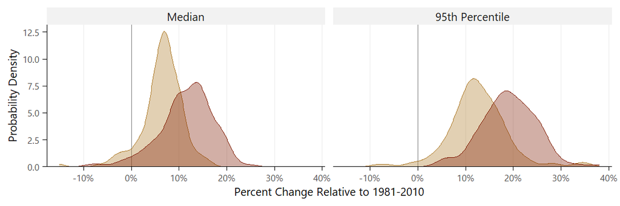

```r
de <- intensity %>%
  mutate(
    id = 1:nrow(.),
    tag = ifelse(id %in% 1:3, paste0('(', letters[4:6], ')'), NA),
    sim_name = factor(sim_name, levels = rev(levels(sim_name)))) %>%
  select(-id) %>%
  filter(stat != 'iqr') %>%
  ggplot() +
  geom_vline(xintercept = 0, color = 'grey50', size = 0.35) +
  geom_density(
    aes(x = value-1, group = sim_name, fill = sim_name, color = sim_name),
    alpha = 0.35, size = 0.35) +
  scale_color_manual(
    'Climate Scenario', values = scico(7, palette = 'roma')[2:1]) +
  scale_fill_manual(
    'Climate Scenario', values = scico(7, palette = 'roma')[2:1]) +
  guides(color = guide_none(), fill = guide_none()) +
  facet_wrap(~stat_name, nrow = 1) +
  scale_x_continuous(
    'Percent Change Relative to 1981-2010', labels = percent) +
  scale_y_origin('Probability Density') +
  theme(
    text = element_text(family = 'Segoe UI', size = 8),
    legend.margin = margin(0,0,0,0),
    legend.position = 'top', #c(0.85,0.5),
    panel.grid.major.x = element_line(size = 0.25),
    strip.placement = 'outside',
    strip.background = element_rect(fill = 'grey95', color = NA),
    strip.text = element_text(size = 8, margin = margin(2,2,2,2)))
de
```

```r
ggsave(a, filename = '_figures/fig5a.png', width = 4.25, height = 2.25, dpi = 600)
ggsave(b, filename = '_figures/fig5b.png', width = 1.75, height = 1.75, dpi = 600)
ggsave(c, filename = '_figures/fig5c.png', width = 4.25, height = 1.5, dpi = 600)
ggsave(de, filename = '_figures/fig5de.png', width = 3, height = 1.75, dpi = 600)
```

The individual figure panels were annotated and combined in Inkscape.

## 4.4) Duration

### Numerical results: Projected relative change in sequence duration

Filter distribution statistics to focus on sequence duration

```r
duration <-
  cbind(
    (stats_ssp245_eoc / stats_ref) %>%
      select(starts_with('duration')) %>%
      setNames(gsub('duration', 'ssp245', names(.))),
    (stats_ssp585_eoc / stats_ref) %>%
      select(starts_with('duration')) %>%
      setNames(gsub('duration', 'ssp585', names(.)))) %>%
    cbind(raster.df(grid_ca) %>% select(-value)) %>%
    slice(index_ca) %>%
    pivot_longer(cols = c(-x,-y)) %>%
    separate(name, into = c('sim', 'stat')) %>%
    mutate(
      sim_name = case_when(
        sim == 'ssp245' ~ 'SSP 2-4.5',
        sim == 'ssp585' ~ 'SSP 5-8.5') %>%
        factor %>% factor(levels = levels(.)[2:1]),
      stat_name = case_when(
        stat == 'med' ~ 'Median',
        stat == 'iqr' ~ 'Interquartile Range (IQR)',
        stat == 'q95' ~ '95th Percentile') %>%
        factor %>% factor(levels = levels(.)[3:1]))
```

Relative duration change for HUC1804:

```r
left_join(
  stats_ssp245_eoc %>%
    select(starts_with('duration')) %>%
    cbind(huc = grid_hucrep[]) %>%
    filter(huc == 1804) %>%
    select(-huc) %>%
    pivot_longer(everything(), names_to = 'stat', values_to = 'ssp245'),
  stats_ref %>%
    select(starts_with('duration')) %>%
    cbind(huc = grid_hucrep[]) %>%
    filter(huc == 1804) %>%
    select(-huc) %>%
    pivot_longer(everything(), names_to = 'stat', values_to = 'hist'),
  by = 'stat') %>%
  mutate(
    stat = gsub('duration.', '', stat),
    stat_name = case_when(
      stat == 'med' ~ 'Median',
      stat == 'q95' ~ '95th Percentile') %>%
      factor %>% factor(levels = levels(.)[3:1])) %>%
  mutate(fact = ssp245/hist, pct = fact-1) %>%
  select(stat_name, hist, ssp245, fact, pct) %>%
  gt %>%
  tab_header(
    'Relative Change Calculation',
    subtitle = 'Sequence Duration (days)') %>%
  fmt_number(c(hist,ssp245), decimals = 0) %>%
  fmt_number(fact, decimals = 2) %>%
  fmt_percent(pct, decimals = 0) %>%
  cols_label(
    stat_name = 'Statistic',
    hist = 'Historic',
    ssp245 = 'SSP2-4.5',
    fact = 'Change Factor',
    pct = 'Percent Change') %>%
  tab_options(
    heading.background.color = '#d9d9d9',
    column_labels.background.color = '#f2f2f2')
```

Relative Change Calculation

Sequence Duration (days)

| Statistic | Historic | SSP2-4.5 | Change Factor | Percent Change |
| --- | --- | --- | --- | --- |
| Median | 20 | 23 | 1.15 | 15% |
| 95th Percentile | 52 | 53 | 1.02 | 2% |

Statewide average relative duration change:

```r
duration %>%
  group_by(sim, stat) %>%
  summarize(mean = Mean(value)-1, sd = sd(value, na.rm = TRUE), .groups = 'drop') %>%
  mutate(sim_name = ifelse(sim == 'ssp245', 'SSP2-4.5', 'SSP5-8.5')) %>%
  pivot_wider(names_from = stat, values_from = c(mean,sd), names_sep = '.') %>%
  select(sim_name, ends_with('med'), ends_with('iqr'), ends_with('q95')) %>%
  gt %>%
  tab_header(
    'Relative Change in Statewide Average Statistics',
    subtitle = 'Sequence Duration (days)') %>%
  tab_spanner('Median', columns = ends_with('med')) %>%
  tab_spanner('IQR', columns = ends_with('iqr')) %>%
  tab_spanner('95th Percentile', columns = ends_with('q95')) %>%
  fmt_percent(c(starts_with('mean'), starts_with('sd')), decimals = 1) %>%
  cols_label(
    sim_name = 'Emission Scenario',
    mean.med = 'Mean', sd.med = 'Std.Dev.',
    mean.q95 = 'Mean', sd.q95 = 'Std.Dev.') %>%
  tab_options(
    heading.background.color = '#d9d9d9',
    column_labels.background.color = '#f2f2f2')
```

Relative Change in Statewide Average Statistics

Sequence Duration (days)

| Emission Scenario | Median Mean | Median Std.Dev. | 95th Percentile Mean | 95th Percentile Std.Dev. |
| --- | --- | --- | --- | --- |
| SSP2-4.5 | 10.9% | 10.5% | 7.6% | 12.4% |
| SSP5-8.5 | 17.9% | 10.0% | 28.4% | 16.8% |

### FIG 6: Sequence duration change

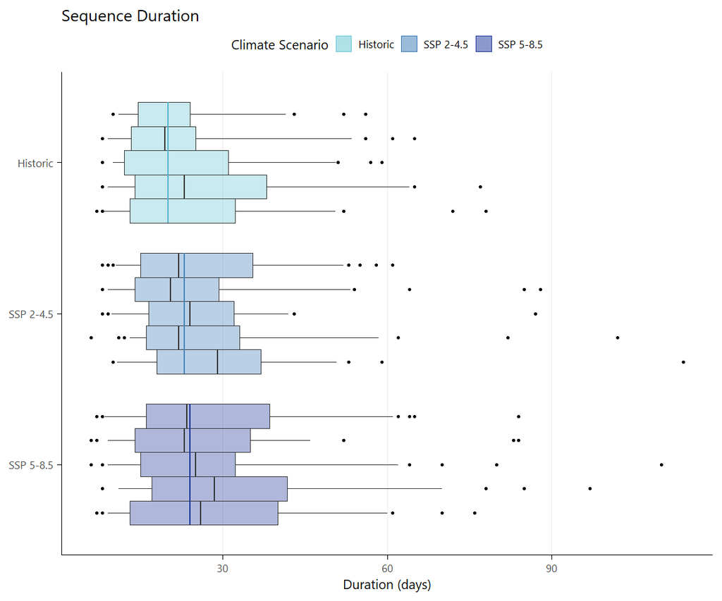

```r
a <- ggplot(stats) +
  geom_ribbon(
    aes(x = duration, group = source, ymin = source_name, ymax = source_name, fill = source),
    color = NA, alpha = 0) +
  # stat_boxplot_custom(
  #   aes(x = duration, y = source_name, group = paste(source,ens), fill = source),
  #   qs = c(.05, .25, .5, .75, .95),
  #   outlier.size = 0.5, size = 0.25, outlier.alpha = 1, alpha = 0.35,
  #   show.legend = FALSE) +
  geom_boxplot(
    data = stats %>%
      mutate(source_name = factor(source_name, levels = c('SSP 5-8.5','SSP 2-4.5','Historic'))) %>%
      group_by(source_name,source,ens) %>%
      summarize(
        y05 = quantile(duration,0.05),
        y25 = quantile(duration,0.25),
        y50 = quantile(duration,0.50),
        y75 = quantile(duration,0.75),
        y95 = quantile(duration,0.95)),
    aes(
      xmin = y05, xlower = y25, xmiddle = y50, xupper = y75, xmax = y95,
      y = source_name, group = paste(source_name,ens), fill = source),
    stat = 'identity', position = 'dodge',
    width = 0.8, size = 0.25, alpha = 0.35, show.legend = FALSE) +
  geom_point(
    data = stats %>%
      mutate(source_name = factor(source_name, levels = c('SSP 5-8.5','SSP 2-4.5','Historic'))) %>%
      group_by(source_name,source,ens) %>%
      mutate(
        y05 = quantile(duration,0.05),
        y95 = quantile(duration,0.95)) %>%
      ungroup %>% group_by(source) %>%
      mutate(
        dodge = seq(-0.32,0.32,length.out = length(unique(ens)))[ens]) %>%
      ungroup %>%
      filter(duration < y05 | duration > y95),
    aes(x = duration, y = as.numeric(factor(source_name))+dodge),
    size = 0.5) +
  scale_fill_manual(
    'Climate Scenario',
    labels = c('Historic', 'SSP 2-4.5', 'SSP 5-8.5'),
    values = scico(7, palette = 'roma')[5:7],
    guide = guide_legend(
      override.aes = list(
        color = scico(7, palette = 'roma')[5:7], size = 0.25, alpha = 0.5))) +
  scale_x_continuous('Duration (days)', breaks = 30*(0:10)) +
  theme(
    text = element_text(family = 'Segoe UI', size = 8),
    panel.grid.major.x = element_line(size = 0.25),
    axis.title.y = element_blank(),
    legend.position = 'top',
    legend.margin = margin(1,1,1,1)) +
  ggtitle('Sequence Duration') +
  geom_segment(
    x = stats %>% filter(source == 'hist') %>% pull(duration) %>% median,
    xend = stats %>% filter(source == 'hist') %>% pull(duration) %>% median,
    y = 2.6, yend = 3.4,
    color = scico(11, palette = 'roma')[8]) +
  geom_segment(
    x = stats %>% filter(source == 'ssp245') %>% pull(duration) %>% median,
    xend = stats %>% filter(source == 'ssp245') %>% pull(duration) %>% median,
    y = 1.6, yend = 2.4,
    color = scico(11, palette = 'roma')[9]) +
  geom_segment(
    x = stats %>% filter(source == 'ssp585') %>% pull(duration) %>% median,
    xend = stats %>% filter(source == 'ssp585') %>% pull(duration) %>% median,
    y = 0.6, yend = 1.4,
    color = scico(11, palette = 'roma')[11])
a
```

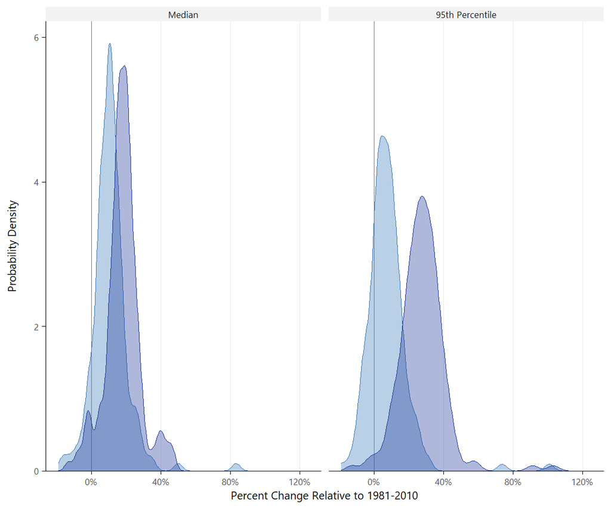

```r
bc <- duration %>%
  mutate(
    id = 1:nrow(.),
    tag = ifelse(id %in% 1:3, paste0('(', letters[2:4], ')'), NA),
    sim_name = factor(sim_name, levels = rev(levels(sim_name)))) %>%
  select(-id) %>%
  filter(stat != 'iqr') %>%
  ggplot() +
  geom_vline(xintercept = 0, color = 'grey50', size = 0.35) +
  geom_density(
    aes(x = value-1, group = sim_name, fill = sim_name, color = sim_name),
    alpha = 0.35, size = 0.35) +
  scale_color_manual('Climate\nScenario', values = scico(7, palette = 'roma')[6:7]) +
  scale_fill_manual('Climate\nScenario', values = scico(7, palette = 'roma')[6:7]) +
  guides(color = guide_none(), fill = guide_none()) +
  facet_wrap(~stat_name, nrow = 1) +
  scale_x_continuous(
    'Percent Change Relative to 1981-2010', labels = percent) +
  scale_y_origin('Probability Density\n') +
  coord_cartesian(xlim = c(NA,1.25)) +
  theme(
    text = element_text(family = 'Segoe UI', size = 8),
    legend.margin = margin(0,0,0,0),
    legend.position = c(0.9,0.5),
    panel.grid.major.x = element_line(size = 0.25),
    strip.placement = 'outside',
    strip.background = element_rect(fill = 'grey95', color = NA),
    strip.text = element_text(margin = margin(2,2,2,2)),
    plot.margin = margin(5,5,5,5))
bc
```

```r
ggsave(a, filename = '_figures/fig6a.png', width = 4.25, height = 2.25, dpi = 600)
ggsave(bc, filename = '_figures/fig6bc.png', width = 4.18, height = 1.75, dpi = 600)
```

The individual figure panels were annotated and combined in Inkscape.

### Numerical results: Super-sequences

Create dataframes

```r
extremes_ref <-
  foreach (i = 1:ncell(grid_ca), .combine = 'rbind') %do% {
    if (progress) setTxtProgressBar(pb,i)
    if (is.null(df_hist[[i]])) rep(NA,5) else {
      temp <- df_hist[[i]] %>%
        filter(seq) %>%
        filter(wateryear(date) %in% 1981:2010) %>%
        group_by(ens,seq.count) %>%
        summarize(duration = seq.duration[1], .groups = 'drop')
      temp %>%
        group_by(ens) %>%
        summarize(n = sum(duration>60)/30) %>%
        right_join(data.frame(ens = unique(df_hist[[i]]$ens))) %>%
        mutate(n = setNA(n,0)) %>%
        right_join(data.frame(ens = 1:5), by = 'ens') %>%
        arrange(ens) %>%
        pull(n)
    }
  } %>% apply(1, Max)
if (progress) cat('\n')

extremes_ssp245_eoc <-
  foreach (i = 1:ncell(grid_ca), .combine = 'rbind') %do% {
    if (progress) setTxtProgressBar(pb,i)
    if (is.null(df_ssp245[[i]])) rep(NA,5) else {
      temp <- df_ssp245[[i]] %>%
        filter(seq) %>%
        filter(wateryear(date) %in% 2061:2090) %>%
        group_by(ens,seq.count) %>%
        summarize(duration = seq.duration[1], .groups = 'drop')
      temp %>%
        group_by(ens) %>%
        summarize(n = sum(duration>60)/30) %>%
        right_join(data.frame(ens = unique(df_ssp245[[i]]$ens))) %>%
        mutate(n = setNA(n,0)) %>%
        right_join(data.frame(ens = 1:5), by = 'ens') %>%
        arrange(ens) %>%
        pull(n)
    }
  } %>% apply(1, Max)
if (progress) cat('\n')

extremes_ssp585_eoc <-
  foreach (i = 1:ncell(grid_ca), .combine = 'rbind') %do% {
    if (progress) setTxtProgressBar(pb,i)
    if (is.null(df_ssp585[[i]])) rep(NA,5) else {
      temp <- df_ssp585[[i]] %>%
        filter(seq) %>%
        filter(wateryear(date) %in% 2061:2090) %>%
        group_by(ens,seq.count) %>%
        summarize(duration = seq.duration[1], .groups = 'drop')
      temp %>%
        group_by(ens) %>%
        summarize(n = sum(duration>60)/30) %>%
        right_join(data.frame(ens = unique(df_ssp585[[i]]$ens))) %>%
        mutate(n = setNA(n,0)) %>%
        right_join(data.frame(ens = 1:5), by = 'ens') %>%
        arrange(ens) %>%
        pull(n)
    }
  } %>% apply(1, Max)
if (progress) cat('\n')
```

Historical vs. projected future spatial coverage of super-sequences:

```r
rbind(
  c('Historic', 'single', Sum(extremes_ref>0) / sum(!is.na(extremes_ref))),
  c('SSP2-4.5', 'single', Sum(extremes_ssp245_eoc>0) / sum(!is.na(extremes_ssp245_eoc))),
  c('SSP5-8.5', 'single', Sum(extremes_ssp585_eoc>0) / sum(!is.na(extremes_ssp585_eoc))),
  c('Historic', 'multiple', Sum(extremes_ref>(1/30)) / sum(!is.na(extremes_ref))),
  c('SSP2-4.5', 'multiple', Sum(extremes_ssp245_eoc>(1/30)) / sum(!is.na(extremes_ssp245_eoc))),
  c('SSP5-8.5', 'multiple', Sum(extremes_ssp585_eoc>(1/30)) / sum(!is.na(extremes_ssp585_eoc)))) %>%
  as.data.frame %>% setNames(c('source', 'super', 'pct')) %>%
  mutate(pct = toNumber(pct)) %>%
  pivot_wider(names_from = super, values_from = pct) %>%
  gt %>%
  tab_header(
    'Super-Sequence Coverage',
    subtitle = 'Percent of Grid Cells Affected over 30 Years (1981-2010 or 2021-2050)') %>%
  fmt_percent(c(single, multiple), decimals = 1) %>%
  cols_label(
    source = 'Emission Scenario',
    single = 'Cells with >0 Super-Sequences',
    multiple = 'Cells with Multiple Super-Sequences') %>%
  tab_options(
    heading.background.color = '#d9d9d9',
    column_labels.background.color = '#f2f2f2')
```

Super-Sequence Coverage

| Emission Scenario | Cells with >0 Super-Sequences | Cells with Multiple Super-Sequences |
| --- | --- | --- |
| Historic | 73.3% | 39.4% |
| SSP2-4.5 | 86.7% | 67.3% |
| SSP5-8.5 | 98.8% | 93.9% |

### FIG 7: Sequence annual frequency as a function of duration

```r
bucket_ref <-
  foreach (i = 1:ncell(grid_ca), .combine = 'rbind') %do% {
    if (progress) setTxtProgressBar(pb,i)
    if (!is.null(df_hist[[i]])) {
      temp <- df_hist[[i]] %>%
        filter(seq) %>%
        filter(wateryear(date) %in% 1981:2010) %>%
        group_by(ens,seq.count) %>%
        summarize(duration = seq.duration[1], .groups = 'drop') %>%
        mutate(duration_cut = cut(duration, breaks = c(0,14,30,60,200)))
      (summary(temp$duration_cut) / length(unique(temp$ens)) / 30) %>%
        as.matrix %>% t %>% as.data.frame
    } else rep(NA,6)
  }
if (progress) cat('\n')
bucket_ssp245_eoc <-
  foreach (i = 1:ncell(grid_ca), .combine = 'rbind') %do% {
    if (progress) setTxtProgressBar(pb,i)
    if (!is.null(df_ssp245[[i]])) {
      temp <- df_ssp245[[i]] %>%
        filter(seq) %>%
        filter(wateryear(date) %in% 2061:2090) %>%
        group_by(ens,seq.count) %>%
        summarize(duration = seq.duration[1], .groups = 'drop') %>%
        mutate(duration_cut = cut(duration, breaks = c(0,14,30,60,200)))
      (summary(temp$duration_cut) / length(unique(temp$ens)) / 30) %>%
        as.matrix %>% t %>% as.data.frame
    } else rep(NA,6)
  }
if (progress) cat('\n')
bucket_ssp585_eoc <-
  foreach (i = 1:ncell(grid_ca), .combine = 'rbind') %do% {
    if (progress) setTxtProgressBar(pb,i)
    if (!is.null(df_ssp585[[i]])) {
      temp <- df_ssp585[[i]] %>%
        filter(seq) %>%
        filter(wateryear(date) %in% 2061:2090) %>%
        group_by(ens,seq.count) %>%
        summarize(duration = seq.duration[1], .groups = 'drop') %>%
        mutate(duration_cut = cut(duration, breaks = c(0,14,30,60,200)))
      (summary(temp$duration_cut) / length(unique(temp$ens)) / 30) %>%
        as.matrix %>% t %>% as.data.frame
    } else rep(NA,6)
  }
if (progress) cat('\n')

bucket <-
  rbind(
    bucket_ref %>%
      cbind(raster.df(grid_huc4) %>% transmute(huc4 = value)) %>%
      slice(index_ca) %>%
      mutate(id = index_ca, source = 'hist'),
    bucket_ssp245_eoc %>%
      cbind(raster.df(grid_huc4) %>% transmute(huc4 = value)) %>%
      slice(index_ca) %>%
      mutate(id = index_ca, source = 'ssp245'),
    bucket_ssp585_eoc %>%
      cbind(raster.df(grid_huc4) %>% transmute(huc4 = value)) %>%
      slice(index_ca) %>%
      mutate(id = index_ca, source = 'ssp585')) %>%
  pivot_longer(cols = c(-id,-source,-huc4), names_to = 'bucket', values_to = 'freq') %>%
  mutate(
    bucket_label = case_when(
      bucket == '(0,14]' ~ 'Duration \u2264 14 Days',
      bucket == '(14,30]' ~ 'Duration = 15-30 Days',
      bucket == '(30,60]' ~ 'Duration = 31-60 Days',
      bucket == '(60,200]' ~ 'Duration > 60 Days') %>%
      factor(levels = c(
        'Duration \u2264 14 Days', 'Duration = 15-30 Days',
        'Duration = 31-60 Days', 'Duration > 60 Days'))) %>%
  pivot_wider(names_from = source, values_from = freq)
```

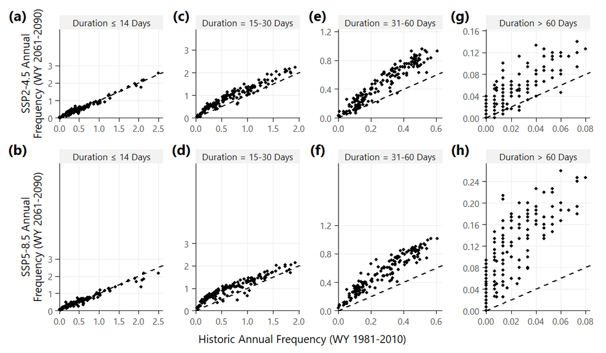

```r
temp <- bucket %>%
  filter(bucket_label == levels(bucket_label)[4]) %>%
  select(hist, ssp245, ssp585) %>%
  apply(2, Max)
ratio <- (temp/temp[1])[-1]

uppers <- bucket %>%
  group_by(bucket) %>%
  summarize(across(c('hist', 'ssp245', 'ssp585'), Max)) %>%
  select(-bucket)

g.high <- list()
for (i in 1:4) {
  temp <-
    ggplot(bucket %>% filter(bucket_label == levels(bucket_label)[i])) +
    geom_point(aes(x = hist, y = ssp245), size = 0.75)
  dx <- ggplot_build(temp)$layout$panel_params[[1]]$x$breaks %>% diff %>% .[1]
  g.high[[i]] <-
    ggplot(bucket %>% filter(bucket_label == levels(bucket_label)[i])) +
    geom_point(aes(x = hist, y = ssp245), size = 0.75) +
    facet_wrap(~bucket_label) +
    scale_x_origin('Historic (1921-2010) Annual Frequency') +
    scale_y_origin(
      'SSP2-4.5 Annual\nFrequency (WY 2061-2090)',
      breaks = seq(0, uppers$ssp245[i]+2*dx, 2*dx)) +
    geom_parity() +
    coord_cartesian(
      clip = 'off', xlim = c(0, uppers$hist[i]), ylim = c(0, ratio[1]*1.1*uppers$hist[i])) +
    theme(
      text = element_text(family = 'Segoe UI', size = 8),
      panel.grid.major = element_line(size = 0.25),
      axis.title = element_blank(),
      strip.background = element_rect(color = NA, fill = 'grey95'),
      strip.text = element_text(margin = margin(2,2,2,2)))
}
g.high[[1]] <- g.high[[1]] + theme(axis.title.y = element_text())

g.low <- list()
for (i in 1:4) {
  temp <-
    ggplot(bucket %>% filter(bucket_label == levels(bucket_label)[i])) +
    geom_point(aes(x = hist, y = ssp585), size = 0.75)
  dx <- ggplot_build(temp)$layout$panel_params[[1]]$x$breaks %>% diff %>% .[1]
  g.low[[i]] <-
    ggplot(bucket %>% filter(bucket_label == levels(bucket_label)[i])) +
    geom_point(aes(x = hist, y = ssp585), size = 0.75) +
    facet_wrap(~bucket_label) +
    scale_x_origin('Historic (1921-2010)\nAnnual Frequency') +
    scale_y_origin(
      'SSP5-8.5 Annual\nFrequency (WY 2061-2090)',
      breaks = seq(0, uppers$ssp585[i]+2*dx, 2*dx)) +
    geom_parity() +
    coord_cartesian(
      clip = 'off', xlim = c(0, uppers$hist[i]), ylim = c(0, ratio[2]*uppers$hist[i])) +
    theme(
      text = element_text(family = 'Segoe UI', size = 8),
      panel.grid.major = element_line(size = 0.25),
      axis.title = element_blank(),
      strip.background = element_rect(color = NA, fill = 'grey95'),
      strip.text = element_text(margin = margin(2,2,2,2)))
}
g.low[[1]] <- g.low[[1]] + theme(axis.title.y = element_text())

layout <- "ABCD\nEFGH"
g.high[[1]] + g.high[[2]] + g.high[[3]] + g.high[[4]] + #g.high[[5]] +
  g.low[[1]] + g.low[[2]] + g.low[[3]] + g.low[[4]] + #g.low[[5]] +
  plot_layout(
    design = layout,
    widths = rep(1,5), heights = c(3,5)) +
  plot_annotation(
    caption = 'Historic Annual Frequency (WY 1981-2010)',
    tag_levels = list(letters[c(1,3,5,7,2,4,6,8)]), tag_prefix = '(', tag_suffix = ')', ) &
  theme(
    plot.tag = element_text(
      family = 'Segoe UI', face = 'bold', size = 10, margin = margin(-5,-5,-5,-5)),
    plot.caption = element_text(size = 8, hjust = 0.5, margin = margin(0,0,0,0)))
ggsave('_figures/fig7_returnperiod.png', width = 6, height = 3.5, units = 'in', dpi = 600)
```

# 5) Discussion

Create dataframes

```r
exceed_ref <-
  foreach (i = 1:ncell(grid_ca), .combine = 'rbind') %do% {
    if (progress) setTxtProgressBar(pb,i)
    if (!is.null(df_hist[[i]])) {
      df_hist[[i]] %>%
        mutate(wy = wateryear(date)) %>%
        filter(wy %in% 1981:2010) %>%
        filter(seq) %>%
        group_by(ens, wy, seq.count) %>%
        summarize(duration = seq.duration[1], .groups = 'drop_last') %>%
        summarize(exceed60 = (sum(duration>60)/length(duration)) > 0, .) %>%
        right_join(expand.grid(ens = unique(df_hist[[i]]$ens), wy = 1981:2010), by = c('ens', 'wy')) %>%
        mutate(exceed60 = setNA(exceed60, FALSE)) %>%
        summarize(across(starts_with('exceed'), mean)) %>%
        right_join(data.frame(ens = 1:5), by = 'ens') %>%
        arrange(ens) %>% pull(exceed60)
    } else rep(NA,5)
  }
if (progress) cat('\n')

exceed_ssp245_eoc <-
  foreach (i = 1:ncell(grid_ca), .combine = 'rbind') %do% {
    if (progress) setTxtProgressBar(pb,i)
    if (!is.null(df_ssp245[[i]])) {
      df_ssp245[[i]] %>%
        mutate(wy = wateryear(date)) %>%
        filter(wy %in% 2061:2090) %>%
        filter(seq) %>%
        group_by(ens, wy, seq.count) %>%
        summarize(duration = seq.duration[1], .groups = 'drop_last') %>%
        summarize(exceed60 = (sum(duration>60)/length(duration)) > 0) %>%
        right_join(expand.grid(ens = unique(df_ssp245[[i]]$ens), wy = 2061:2090), by = c('ens', 'wy')) %>%
        mutate(exceed60 = setNA(exceed60, FALSE)) %>%
        summarize(across(starts_with('exceed'), mean)) %>%
        right_join(data.frame(ens = 1:5), by = 'ens') %>%
        arrange(ens) %>% pull(exceed60)
    } else rep(NA,4)
  }
if (progress) cat('\n')

exceed_ssp585_eoc <-
  foreach (i = 1:ncell(grid_ca), .combine = 'rbind') %do% {
    if (progress) setTxtProgressBar(pb,i)
    if (!is.null(df_ssp585[[i]])) {
      df_ssp585[[i]] %>%
        mutate(wy = wateryear(date)) %>%
        filter(wy %in% 2061:2090) %>%
        filter(seq) %>%
        group_by(ens, wy, seq.count) %>%
        summarize(duration = seq.duration[1], .groups = 'drop_last') %>%
        summarize(exceed60 = (sum(duration>60)/length(duration)) > 0) %>%
        right_join(expand.grid(ens = unique(df_ssp585[[i]]$ens), wy = 2061:2090), by = c('ens', 'wy')) %>%
        mutate(exceed60 = setNA(exceed60, FALSE)) %>%
        summarize(across(starts_with('exceed'), mean)) %>%
        right_join(data.frame(ens = 1:5), by = 'ens') %>%
        arrange(ens) %>% pull(exceed60)
    } else rep(NA,4)
  }
if (progress) cat('\n')
```

Percentage of years with super-sequences:

```r
data.frame(
  `Historic` = exceed_ref %>% apply(1, Mean),
  `SSP2-4.5` = exceed_ssp245_eoc %>% apply(1, Mean),
  `SSP5-8.5` = exceed_ssp585_eoc %>% apply(1, Mean)) %>%
  slice(index_ca) %>%
  pivot_longer(everything()) %>%
  group_by(name) %>%
  # as_tibble() %>%
  summarize(across(value, .fns = list(mean = mean, sd = sd, rp = function(x) 1/mean(x)))) %>%
  # pivot_longer(-name, names_to = 'stat')
  gt %>%
  tab_header('Percent of Years with Super-Sequences') %>%
  fmt_markdown(name) %>%
  fmt_percent(c(value_mean, value_sd), decimals = 1) %>%
  fmt_number(value_rp, decimals = 1) %>%
  cols_label(
    name = 'Emission Scenario',
    value_mean = 'Mean (%)',
    value_sd = 'Std. Dev. (%)',
    value_rp = 'Return Period (yrs)') %>%
  tab_options(
    heading.background.color = '#d9d9d9',
    column_labels.background.color = '#f2f2f2')
```

Percent of Years with Super-Sequences

| Emission Scenario | Mean (%) | Std. Dev. (%) | Return Period (yrs) |
| --- | --- | --- | --- |
| Historic | 1.9% | 1.9% | 53.0 |
| SSP2.4.5 | 4.2% | 3.6% | 23.9 |
| SSP5.8.5 | 10.5% | 6.3% | 9.5 |